# Parallel programming in Python

### ⓒ Jiří Fišer, MMXX, Faculty of Science, UJEP, Ústí nad Labem, Czech Republic

[figure not shown]

1. Brief introduction to parallel programming ([Jupyter](https://colab.research.google.com/github/JiriFiser/python-conda_pip/blob/master/p1.ipynb))
- Flynn's taxonomy
2. Parallelism in Python ([Jupyter](https://colab.research.google.com/github/JiriFiser/python-conda_pip/blob/master/p1.ipynb))
3. Package multiprocessing ([Jupyter](https://colab.research.google.com/github/JiriFiser/python-conda_pip/blob/master/p2.ipynb))
- Process pool and jobs mapping
- Explicit workers and queues
- Overview of others tools of `multiprocessing` library
4. MPI for Python ([Jupyter](https://colab.research.google.com/github/JiriFiser/python-conda_pip/blob/master/p3.ipynb))
- Point-to-point communication
- Collective communications
5. MPI over Numpy arrays ([Jupyter](https://colab.research.google.com/github/JiriFiser/python-conda_pip/blob/master/p4.ipynb))
6. Auto parallelization ([Jupyter](https://colab.research.google.com/github/JiriFiser/python-conda_pip/blob/master/p5.ipynb))
- First use case: Sum of differences of adjacent elements
- Second use case: Cross distances of 2D points

# 1. Brief introduction to parallel programming

Parallel programming is programming paradigm which make possible **utilization of hardware parallelism** (e.g. computer clusters or multicore CPUs) for more efficient (i.e. faster) programs.

The low level parallel programming is most typical case of **asynchronous programming** i.e. programming in which the time ordering of instruction is undefined. For two instruction there is no warranty that one instruction is executed before another or vice versa (there are also a certain probability that both instructions are performed simultaneously).

The *asynchronous programming are inherently nondeterministic* — the result (output) is not unambiguously determined by inputs (basic principles of usable algorithms). In typical case the result is often valid but there is nonzero probability of invalid results (the instructions are performed in a wrong order). There is also possibility of infinite loops or endless waitings in asynchronous programs (deadlock).

The modern approaches to parallel programming minimize nondeterminism or make it impossible but this approach can **increase dependency between parallel parts of code** (some code is waiting for execution of another code). This **increases overhead** of program making it less parallel and therefore less efficient.

The character of parallel programming strictly depends on a type of parallel hardware architecture. The most general classification of parallel system provides Flynn's taxonomy.

## Flynn's taxonomy

The four categories defined by Flynn are based upon the number of concurrent instruction (or control) streams and data streams available in the architecture (two dimensional classification)

| data/instruction | single i. | multiple i. |
| --- | --- | --- |
| single d. | SISD | (MISD) |
| multiple d. | SIMD | MIMD |

### SISD

SISD category contains nonparallel computers of von Neumann or Harvard architecture. Only one instruction on one data input (i.e. register) is performed in one processing unit at one time.

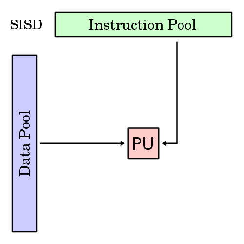

> SISD computers also support some type of hardware parallelism which is hidden from the point of view of application code (code uses serial instruction which are automatically parallelized)
> - bit parallelism = bitwise operation are performed on several bits t once
> - superscalar processors = superscalar processor can execute more than one instruction during a clock cycle by simultaneously dispatching multiple instructions to different execution units on the processor.

### MISD

This category is uncommon. It is generally used for fault tolerance. Heterogeneous systems operate on the same data stream and must agree on the result.

### SIMD

A single instruction operates on multiple different data outputs at once by multiple functional units (i.e multiple ALUs or FPUs).

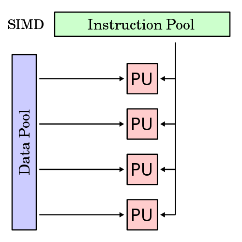

The SIMD architecture make possible **vectorization** i.e. performing single instruction on whole vector of numbers at one time (also denoted as data level parallelism).

The SIMD units and appropriate instructions sets are provided by mainstream CPUs. Intel processors offers SSE instruction set (Streaming SIMD Extensions), ARM supports NEON extension. The most advanced SIMD is provided by GPUs which have several hundreds functional units for integer and floating points operations.

The modern C and C++ language compilers offers automatic generation of vectorized code for some simple construct (e.g. for-loop), but often an additional information is necessary. The support of vectorization is also included in most packages (e.g. Matlab, Mathematica or Intel implementation of NumPy).

### MIMD

This category encompasses system in which at any time, different processors may be executing different instructions on different pieces of data.

[figure not shown]

The MIMD system can be categorized to two main subcategories:

1. system with distributed memory
2. system with shared memory

#### System with distributed memory

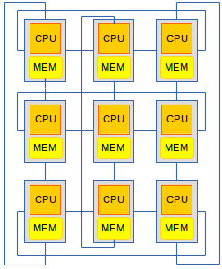

System with distributed memory (loosely coupled systems) contains a set of nodes. Every nodes contains processor and local memory. Nodes are connected by interconnection network which makes possible exchange of messages and data among nodes.

There are two incarnation of loosely coupled systems:

1. **computer clusters** (massively parallel systems, supercomputers)  
   = single computer with dedicated (switch-less) very fast interconnection network and typical network topology (e.g. hypercube or toroidal grid).

[figure not shown]

> **Task**: Describe typical topologies of computer clusters (hypercube, torus, etc.) especially from the point of view of efficency (the shortest path) and extensibility.
1. **network grid computing**  
   = system of several computers which are connected by normal network (e.g. Internet) and typically are coupled only for several task (see for example [Boinc](https://boinc.berkeley.edu/).

Main pros:

- highly scalable (up to billions of CPUs or GPUs)
- no problems with memory access synchronization

Main cons:

- the physical copying of data between nodes (optimization is possible)
- standard (uniprocessor) programming techniques are not usable, the message passing paradigm has to be applied

> **Task:** The computer clusters and network grids are differentiated by interconnection network. Do a technology survey of interconnection networks of computer clusters (e.g. Infiband) and network grids (1Gb or 10Gb). Pick main defining features.

#### System with shared memory

In typical computer system with shared memory (= *tightly coupled system*) CPUs access single memory via shared bus.

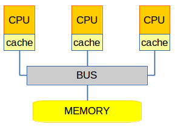

Homogeneous system in which all the CPUs are interchangeable (i.e. they can execute the code of operating system and all applications) are denoted as system with **symmetric multiprocessing** (SMP).

> The processor in SMP computer may not be identical but have to support common instruction set. For example in many ARM based system the big.LITTLE technology is used a that uses two types of processors.

> »LITTLE« processors are designed for maximum power efficiency while »big« processors are designed to provide maximum compute performance.

The vast majority of system with shared memory are SMP system therefore SMP are practical synonym for tightly coupled system.

SMP system are ubiquitous in the desktop and mobile segments where CPUs with several cores are norm (the multicore processors are are currently the main means of improving performance of computers)

Main pros:

- one instance of normal operating system is sufficient (modern operating systems have SMP support)
- parallel programs can be based on uniprocessor code (in some situation only simple annotations is sufficient)
- communication between processors is very efficient

Main cons:

- the shared is bottleneck (only one processor can access memory at one time) ⇒ local memory cache (per CPU) is mandatory and critical part of system
- problem with memory coherence (all CPus have to see identical memory status)  
  ⇒ cache coherence (the hardware protocol of data exchange between caches is needed)

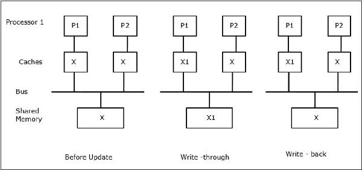

- limited scalability — the memory (bus) bottleneck permits only small number of processors (8 to 16)

> **Task:** Discuss problem of cache coherency and optimization of data structures for maximal cache efficeincy (cache friendly code, see for example [Optimizing software in C++: An optimization guide for Windows, Linux and Mac platforms](https://www.agner.org/optimize/optimizing_cpp.pdf)).

#### NUMA systems

The disadvantages of both approaches (distributed and shared memory systems) can be partially eliminated with system which combine features of both systems.

In these system the CPUs (or group of CPUs) have local memories but there exists global shared memory also. Moreover the CPUs have access to local memories of other CPUs (or external groups) but these access is slower then access to local memories (by several order of magnitude). The access to shared memory is also slower (and it can depend on core and segment of physical address space). This architecture is called **NUMA** (*Non-uniform memory access*) and makes possible computers with several tens of processors managed by normal operating systems.

Main pros:

- system support parallel programs using message passing (created primarily for loosely coupled systems) and also programs utilizing shared memory (created for multicore SMP systems) with reasonable efficiency
- medium degree of scalability (tens of CPUs)

Example of NUMA processors: Xeon Phi (see Figure) and AMD ThreadRipper

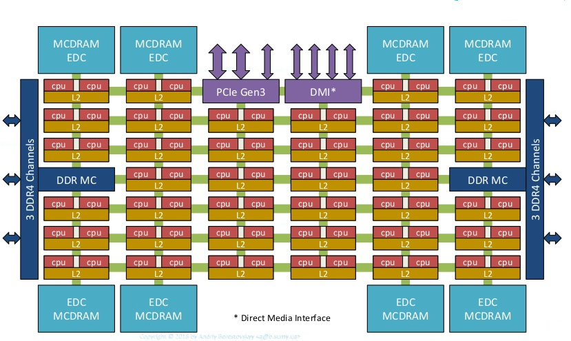

(copyright Andriy Berestovskyy, 2018, see [presentation](https://www.slideshare.net/AndriyBerestovskyy/xeon-what-new-intel-xeon-processors-with-many-integrated-core-mic-architecture))

# 2. Parallelism in Python

Python programming language is high level language which is not primarily optimized for high performance computing. The core language does not support hardware threads and therefore the language does not offer simple tools for parallelism based on shared memory (i.e. most effective parallelism in multicore systems).

The Python support of threads is limited to software threads which do not run concurrently because the Python interpreter uses global lock (GIL = Global Interpreter Lock), see e.g. [What is the Python Global Interpreter Lock (GIL)?](https://realpython.com/python-gil/)

> The global lock is possible to circumvent in code which does not directly interact with Python object, but this is possible only in non Pythonic code (in C language or in Cython). For example C code which operates on NumPy arrays (more precisely on memory buffers of this arrays) can performs operation without acquisition of GIL. This makes possible low level parallelization in CPU bounded code.

There is only one way of elimination of global lock is parallelism based on multiple process (= multiprocessing). Processed do not share memory and interprocess communication is based on software communication channels (e.g. pipes or local network sockets). This approach is identical to message passing mechanisms of loosely based systems (it is defacto software emulation of loosely based system on SMP or NUMA architecture).

Pros:

- applicable to both types of MIMD systems
- memory synchronization is trivial (no race conditions error)

Cons:

- reduced efficiency (data are copied between address spaces via kernel of operating system or via network, some copying can be eliminated by interprocess shared memories)

The two main implementation of message passing paradigm in Python:

1. **multiprocessing package** — standard package, simple interface but limited to Python only (and SMP system or small network adhoc grids)
2. **MPI for Python** (mpi4py) — Python port of standardized and portable message-passing system designed to function on a wide variety of parallel computers (widely used for supercomputers and high performance computing cluster). It offers more complex communication tools.

# 3. Package multiprocessing

Multiprocessing package is standard package for process-based parallel computations in Python (from Python 2.6 onwards).

The package support two interfaces:

- high level interface based on process pools and mapping of jobs
- low level interface with explicit message passing via communication queues (this interface is more complex but more flexible)

## Process pool and jobs mapping

**Process pool** is set of processes (created by operating system) which are designed to perform computational jobs (= worker processes). Jobs are unary function which transform one value (input) to another value (output). The every job is executed by one worker process but one process can execute several jobs. For reasonable efficiency (overhead has to be negligible to total computing time) the number of jobs must be greater than number of worker processes (preferably significantly greater).

The basic method of performing jobs is calling of job function on every item of an iterator and gathering of results in new list (mapping). Individual jobs are automatically allocated to worker processes in pool and executed in parallel manner. This function is parallel version of standard Python `map` function (but returning list not iterator).

Maximal number of jobs executed in parallel is equal to number of worker processes (but in reality is smaller).

The basic pattern of parallel mapping is not complicated:

```python
import multiprocessing
from os import getpid

def worker(input):  # job
    print(f"Task {input} in process {getpid()}")
    output = input
    return output

if __name__ == '__main__': # main task (manager)
    with multiprocessing.Pool() as pool: # creation of pool
        print(f"Main process {getpid()}")
        print("Go parallel!")
        result = pool.map(worker, range(8))  # map job on items of iterator
        print("After barrier ... return to serial (uniprocess) flow")
        print(f"Result: {result}")
```

```
Task 2 in process 6068
Task 0 in process 6066
Task 4 in process 6068
Task 3 in process 6069
Task 5 in process 6068
Task 1 in process 6067
Task 6 in process 6066
Task 7 in process 6069
Main process 5909
Go parallel!
After barrier ... return to serial (uniprocess) flow
Result: [0, 1, 2, 3, 4, 5, 6, 7]
```

Job function is ordinary Python function with one parameter.

The main program (it should be in `if __name__ == '__main__'` section) is executed only by main process (see its process identifier in first `print`).

The pool of process is created as side effect of constructor of class `Pool`. The default number of worker processes is equal to number of cores of local system (information provided by OS, including virtual cores of simultaneous multithreading e.g. Intel's hyperthreading). A different number can be specified by constructor parameter.

The creation of worker processes which is central part of pool's creation is **expansive operation** (relatively slow and resource-intensive) therefore the pool is not limited to one mapping and exists from its creation to explicit termination (or to finishing of program). On the other hand the worker process *should be disposed immediately after the last use* preferably using context management protocol (= `with` statement)

The central part of program is calling of method `map` on pool object. In this call the second parameter (iterator) is iterated and individuals items are transferred to worker processes (`self` of method) and in this processes the job function (first parameter) is performed on these items. Results are transferred back from worker processes to main process and are collected to list (in the corresponding order).

For system with at least two processors is a fact, that

1. the order of job function invocation (and every part of this function) is unpredictable ⇒ the job function can not have side effects if the condition of determinism is to be met (same result for the same input data)
2. the concrete distribution of items to worker processes is unpredictable and real workload can be irregular.

After invocation of map method there is **barrier** i.e. main process waits for completion of all jobs (i.e. list of results is complete).

> **Quiz**: Why our first example program is not real parallel program (for high performance computing)?

For real try-out of parallelism we need jobs which are CPU-bounded with jobs with duration at least of order of milliseconds.

For second example I have chosen the Miller-Rabin test of primality. This test determines whether a given number is prime. The test is probabilistic algorithm and therefore result can be invalid (composed number is marked as prime number) but this probability is lesser then $4^{-k}$.

The implementation is taken from rosettacode.org,

```python
import random

def is_prime(n, k=8):
    """
    Miller-Rabin primality test.

    Parameters:
        n: has to be integer >= 10
        k: number of trials

    Returns:
        False means n is certainly not prime. True means n is very likely a prime.
    Taken and slightly simplified from:
    https://rosettacode.org/wiki/Miller%E2%80%93Rabin_primality_test#Python:_Probably_correct_answers
    """
    s = 0
    d = n-1
    while d%2==0:
        d>>=1
        s+=1

    def trial_composite(a): # closures of `s` and `d`
        if pow(a, d, n) == 1:
            return False
        for i in range(s):
            if pow(a, 2**i * d, n) == n-1:
                return False
        return True

    for i in range(k):# trials
        a = random.randrange(2, n)
        if trial_composite(a):
            return False
    return True
```

```python
# we try code for small numbers (only primes > 10  are supported)

[i for i in range(10,30) if is_prime(i)]
```

```
[11, 13, 17, 19, 23, 29]
```

For test of multiprocessing we will print all primes (i.e. with strong suspicion of primality) in some intervals.

Two typical cases leading to CPU intensive calculation exists:

- large range of small numbers (e.g. billions of number of order $2^{31}$)
- small range of very big numbers (e.g. thousands of number of order $2^{1024}$)

For parallel executing the second case is better. The first calculation compute a lot of very small job (job durations in µs) with high overhead (only simple calling of empty Python function lasts of tenths of µs).

The duration of jobs in the second case is in order of milliseconds (i.e at lest 1000x greater).

> **Task**: Try real execution time in next notebook cell. The execution time for very small numbers (n = 10) reflects only overhead (time for numerical computation is negligible).

The `%timeit` is magic command of IPython server of Jupyter notebook which provides simple benchmarking. It print mean and standard deviation of duration of line

```python
n = 2**1024 # test for 10, 2^31, or 2^1024
%timeit [is_prime(i) for i in range(n, n+1000)]
```

```
6.74 s ± 105 ms per loop (mean ± std. dev. of 7 runs, 1 loop each)
```

The basic parallel version for searching of all primes in a range is simple. The job input is a number and output is this number (if it is prime) or None (otherwise). The main process only filter values which are numbers. This approach makes main program more straightforward.

```python
import multiprocessing

def worker(n):  # job
    return n if is_prime(n) else None

if __name__ == '__main__': # main task (manager)
    with multiprocessing.Pool(6) as pool: # creation of pool
        min = 2**1024 # very big number (aprox. 300 decimal digits)
        %timeit pool.map(worker, range(min, min+1000))
        result = pool.map(worker, range(min, min+1000)) # for debugging
        print([x for x in result if x is not None])
```

```
2.22 s ± 183 ms per loop (mean ± std. dev. of 7 runs, 1 loop each)
[179769313486231590772930519078902473361797697894230657273430…]
```

Benchmark for my *Intel Core* quad core notebook processor (i7-10510U) returns this values:

| workers | time | speedup |
| --- | --- | --- |
| 1 | 6.69 | 1.0× |
| 2 | 3.61 | 1,85× |
| 4 | 2.12 | 3.15× |
| 6 | 2.22 | 3.01× |

> **Task**: Perform benchmarking for your CPU (for n = 1, 2, 4, .. n+2 threads where is number of cores) and discuss results. Solve Amdahl's law for your results (the proportion of paralellized code should be sumilar to my results). Calculate estimation of speedup for 32 processors.

The parallelizing part of is not optimal. The creation of list of return values (i.e. list of prime numbers and Nones) in `result` variable is useless, because these list can exist only in two line and then it can be destroyed. The list comprehension create list which contains only numbers and which is significantly smaller (primes are rare for big numbers, in range $[2^{1024},2^{1024}+100)$ only prime exist.

The better solution is using of method `imap` that return lazy iterator (the method return iterator immediately, however the code is waiting for results in looping over this iterator i.e. in comprehension in our example). The big temporary list is eliminated.

The `imap` iterator yields results of jobs in the original order (i.e. the first item is transformed first item of input iterator, the second item is transformed second item of input iterator, etc). If the order is not important, the method `imap_unordered` is more efficient (the main program need not to wait for completion of slower jobs). In our example the order si not important (if so, then the short list of primes can be sorted).

```python
import multiprocessing

def worker(n):  # job
    return n if is_prime(n) else None

if __name__ == '__main__': # main task (manager)
    with multiprocessing.Pool(4) as pool: # creation of pool
        min = 2**1024 # very big number (aprox. 300 decimal digits)
        %timeit [x for x in pool.imap_unordered(worker, range(min, min+1000))
                 if x is not None]
        print([x for x in pool.imap_unordered(worker, range(min, min+1000))
                         if x is not None])
```

```
2.06 s ± 168 ms per loop (mean ± std. dev. of 7 runs, 1 loop each)
[179769313486231590772930519078902473361797697894230657273430…]
```

The benchmark of this code shows only insignificant speedup of the parallel code (if any) but this is expected for code with 92% proportion of parallelized code). But for code with smaller jobs (i.e. $min \ll 2^{1024})$ the reduction of overhead can be more significant.

But there is another target of optimization, the transfer of values from main process to workers and vice versa. The transfer of `None` values and relatively small integers is cheap (16 byte for none and 164 byte for number $2^{1024}$ on my system) but for larger intervals the transfer of bulk of `None` values can significantly influence overhead (prime numbers are rare).

This type of optimization is not feasible with jobs mapping because every function in Python returns value (`None` if no `return` statement is present).

## Explicit workers and queues

Explicit cretation of worker process is possible by instantiation of `multiprocessing.Process` and calling its `start` method.

The constructor of `Process` object has two important keyword parameters:

- `target`: function which are executed by worker process
- `args`: arguments of worker (they are transfered to worker process and passed to `target` function

For communication between main process and worker (interprocess) queues can be utilized.

Multiprocessing queues have only two essential methods:

- `put`: puts (pushes) python object to the queue (only object which are pickable are supported, the object is pickled and saved to the shared queue)
- `get` gets () python object from the queue. If the queue is empty the process (calling method) is blocked until an item is available.

The common models of communication requires at least two queues: the first one transfers data from main process to (all) workers, the second queue transfers data in the opposite direction. The queues provided by multiprocessing library support only simple popping i.e. only value from top of queue are popable (others values are not available). Therefore only one stream of values is achievable.

```python
from  multiprocessing import Queue, Process, cpu_count

def worker(tasks, results):  # job (queues are parameters)
    for task in iter(tasks.get, None):  # while the stop task is not reached
        if is_prime(task):      # if number is prime
            results.put(task)   # put its to result queue
    results.put(None)  # put stop value to result queue (worker is finished)

if __name__ == '__main__': # main task (manager)
    n = cpu_count() # number of workers
    print(f"number of CPUs: {n}")
    min = 2**1024 # very big number (aprox. 300 decimal digits)
    task_queue = Queue()  # queue of tasks (from main task to workers)
    result_queue = Queue() # queue of results (from workers to main task)
    for _ in range(n):
        p = Process(target=worker, args=(task_queue, result_queue))
        p.start() # start of newly created worker processes
    for i in range(min, min+1000):
        task_queue.put(i) #  send new task for workers
    for _ in range(n):
        task_queue.put(None) # send stop task (for each worker)

    while n > 0:  # while main task has not received all stop (result) values
        r = result_queue.get() # get from results queue a value
        if r is None:  # if the value is None (i.e. stop value)
            n -= 1  # the number of running tasks is decremented
        else:
            print(r) # else number (prime) is printed
```

```
number of CPUs: 4
179769313486231590772930519078902473361797697894230657273430…
```

The most visible complication of the code is a elimination of perpetual blocking of workers and main process in `get` method of queue. Without sending of stop values (represented by `None`) the workers would wait for more task indefinitely, because after processing of all task the task queue is invariably empty and `get` method is blocking on empty queue). In a similar way the main task would be indefinitely blocked on empty result queue.

For this reason the main task putss `n`-times stop value (`n` = number of worker) to task queue just one for each worker process. The each worker process gets just one stop value (after normal task inputs) and resend it to main task by result queue. It is clear that main process has to wait for `n` stop values (the stop values can be interleaved by numbers but `n`-th stop value in queue is definitely the last value in queue).

If the number of results is known in advance the stop values in results queue are not necessary (stop values in tasks queue are always required because the number of task values processed by a working process is not deterministic)

## Overview of others tools of `multiprocessing` library

- alternative communications channels (transfering or sharing simple units)
  - *pipes* (bidirectional data streams with two ends)
  - *shared values* (using shared memory, the utilization of synchronization primitives is required!)
  - *manager processes* which make possible remote call (i.e. call methods of objects in another process = in another memory space). The communication with manager process is also possible by mean of TCP/IP. Therefore the small (ad hoc) clusters can be based only on multiprocessing library (the manager process acts typically as a communication node between workers and is typically realized by main process)
- synchronization primitives (useful for shared values) -

The high performance processing should avoid explicit synchronizing or minimize it, because brings:

- **performance penalty**: the code can not be executed in parallel by all processes (typically only by one process, see Amdahl's Law).
- **overhead**: synchronization primitives are realized by system calls which utilize thousands of CPU cycles.
- **potential deadlock**: misuse of synchronization can result in *deadlock* Deadlock is situation when one or more often two or more process are they are forever blocked (= they do not execute any code). The risk of deadlock is also in program which use only communication channels (e.g. queues) but deadlocks based on misusing of synchronization calls are more difficult to detect and debug. The deadlock occurs only sometimes (nondeterminism!) and often with with almost negligible probability (almost is not completely!)
- *nondeterministic output*: program occasionally returns invalid results which is almost but not quite correct (if the synchronization is almost correct but insufficient = under-synchronization)

Following (artificial) example presents situation where the explicit synchronization is natural (at the first sight, in reality the example is vary badly designed!)

```python
import numpy as np
from multiprocessing import Value, Pool

s = Value('d', 0.0) # wrapper of shared value (value has type `double`)

def summator_faulting(subarray):
    global s  # declaration of global value
    for x in subarray:
        s.value += x # incrementation of shared value (non-atomic operation!)

p = Pool()
v = np.ones(100_000)
p.map(summator_faulting, np.array_split(v, 10))
print(s.value)
```

```
37581.0
```

In this example a huge numpy array is split into ten subarrays (the `numpy.array_split` returns list of numpy arrays with the same size or almost the same size if regular split is not possible). The worker process receives subarray and in loop it increments the shared value (value is shared by all processes and are wrapped in auxiliary object which are constructed by `multiprocessing.Value` constructor).

The expected value of shared object is sum of all items of huge array i.e. in our example 100 000 (array constains 100 000 items with value 1). But in reality the value is much smaller (value is random, and is approximately 40 000 in my computer).

The problem is a possibility of one type of concurrent execution of three parts (instruction of real or virtual CPUs) of incrementation:

- LOAD: copy value from shared memory to CPU register
- INC: incrementation of CPU register
- SAVE: copy value from register to memory

CPU register are not shared and only on CPU register the real incrementation (and other numeric operation) can be provided.

If the incrementation is processed concurrently by two processes, the order of instruction is arbitrary (all combination is possible but they have different probabilities). One order of these instruction is depicted on the following figure.

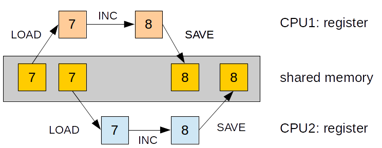

In this figure two incrementation is processed by the contents of shared memory is changed only once (from 7 to 8). This *race condition* (= concurrency resulting in invalid output) has probability 50% on my computer and it is source of invalid summation (some incrementations are overwritten and therefore effectively eliminated).

The solution is seemingly simple — utilization of synchronization lock which ensures that only one process (= only one CPU) can execute code (= *mutual exclusion*). Lock protects code between two points:

- lock acquisition (locking)
- lock release (unlocking)

In Python the `with` statement is optimal for lock management.

```python
import numpy as np
from multiprocessing import Value, Pool

s = Value('d', 0.0) # wrapper of shared value (value has type `double`)

def summator_veryslow(subarray):
    global s  # declaration of global value
    for x in subarray:
        with s.get_lock(): # lock provided by wrapper
            s.value += x # incrementation of shared value (non-atomic operation!)

p = Pool()
v = np.ones(100_000)
p.map(summator_veryslow, np.array_split(v, 10))
print(s.value)
```

```
100000.0
```

The result is correct but the code is very slow because every incrementation (de facto three CPU instruction) is accompanied by call of two methods of lock objects which encapsulate very slow system call. The overhead is gigantic.

Had we moved the `with` statement out of `for` loop, the overhead would be reduced but the code would not be parallel anymore (only one worker could be run at one time).

The best solution is trivial - to minimize access to shared memory. The worker can sum to local variable and to shared value add this partial sum at once. (adding is associative operation).

```python
import numpy as np
from multiprocessing import Value, Pool

s = Value('d', 0.0) # wrapper of shared value (value has type `double`)

def summator_standard(subarray):
    global s  # declaration of global
    localsum = 0 # local (partial sum)
    for x in subarray:
        localsum += x # incrementation of local (partial) sum
    with s.get_lock():  # incrementation must be protected
        s.value += localsum  # but is executed only once for a worker

p = Pool()
v = np.ones(100_000)
p.map(summator_standard, np.array_split(v, 10))
print(s.value)
```

```
100000.0
```

This solution returns correct result and its efficiency is reasonable. The overhead is also concentrated to locking but lock is used only once per worker processes. The shared value and lock is possible to eliminate by output of partial sum by workers and top level summation in main process (this does not decrease parallelism because the top level summation is already in locked section).

```python
import numpy as np
from multiprocessing import Value, Pool

def summator_best(subarray):
    localsum = 0 # local (partial sum)
    for x in subarray:
        localsum += x # incrementation of local (partial) sum
    return localsum # return partial sum to main process

p = Pool()
v = np.ones(100_000)
r = sum(p.imap_unordered(summator_best, np.array_split(v, 10))) # sum of partial sums
print(r)
```

```
100000.0
```

The worker process is marked as *the best one* but this is true only in general case i.e. for systems where shared memory may not available. The subarrays with ten thousand of items have to pickled and transfered from one process to another one (=size of subarray is cca 80 KiB). In system with the shared memory this overhead can be eliminated. All processes (i.e. main process a and workers) can share whole array. The synchronization is not necessary because workers do not change shared array and even if they do worker uses only its subarray and these subarray have no intersection (= they are disjunct).

The `multiprocessing` module supports shared arrays but these arrays are not compatible with numpy arrays and therefore this solution is not very useful (`multiprocessing` array provide only basic initialization = zeroing and simple 1D indexing).

The more advanced implementation of summation and other reductions (= reduction of array to one scalar by a binary operations) offers MPI approach.

# 4. MPI for Python

**MPI** (*Message Passing Interface*) is defacto standard for high performance parallel computing for systems with distributed memory (computer cluster, grid computing). But design of MPI allows also optimization for systems with shared memory (and this optimization is often implemented).

main advantages:

- optimized implementation for all typical architectures of parallel computers (including optimization for topology of nodes in big supercomputers)
- the transcription to more typical HPC languages (C and Fortran) is straightforward (Python can serve as trial platform)

Main disadvantages:

- MPI support is not part of standard libraries and therefore the installation and configuring is not trivial
  1. the MPI has to be installed and properly configured. In the environment of typical supercomputers the MPI is installed a configured by admins.

     For desktop computers the universal open-source implementation exists (*OpenMP*, *MPICH*). The installation and configuration of this packages is out of focus of this text. For Linux and SMP system (multicore processors) the installation and basic configuration is trivial (`apt-get` + default configuration).

     *Intel Python* contains MPICH implementation in its base installation.
  2. Python module `mpi4py` has to be installed (e.g. by *pip*).
  3. MPI program must be invoked by a MPI manager (several alternatives exists but `mpiexec` is the most standard)

     The shotest command line for mpixec:

     `mpiexec python [pyfile] [python_arg]`

     The more typical form set number of local process explicitly:

     `mpiexec -n [number_of_processes] python [pyfile] [python_arg]`

     > Notice: *Intel Python* installation contains manager mpiexec.hydra, this manager do not cooperate with ipcluster for my actual version of Intel Python)

The utilization of MPI in Jupyter notebook require invocation of `ipcluster` server (for now versions ipyparallel module must be instaled). This invocation is possible inside notebook (both arguments are mandatory)

```python
!ipcluster start --n=4 --daemonize --engines=MPIEngineSetLauncher
```

The second (mandatory) step in configuration is creation of client object (instance of `ipyparallel.Client` in notebook). The object has to be referenced by variable but this variable does not have to be used (only existence of the client object is sufficient). The printing of `ids` property is only for testing purposes.

```python
from ipyparallel import Client
c = Client()
print(c.ids)
```

```
[0, 1, 2, 3]
```

If all is well the output is list of values 0 … n-1 where the n is number of CPUs (including virtual processors).

Now we can run first MPI program (only for testing purposes).

```python
%%px
from mpi4py import MPI

comm = MPI.COMM_WORLD
rank = comm.Get_rank()
size = comm.Get_size()
print(f'My rank is {rank} of {size}')
```

```
[stdout:0] My rank is 0 of 4
[stdout:1] My rank is 1 of 4
[stdout:2] My rank is 2 of 4
[stdout:3] My rank is 3 of 4
```

This simple program has three initial section which will be shared among all our MPI programs:

- magic command for `IPython` (used only in Jupyter notebooks). This command execute cell in all engines (= processes created by `ipcluster` which are available by client object). In normal scripts this magic command is not applicable (multiple execution of python compiler is provided by MPI manager `mpiexec`).
- imports MPI object from `mpi4py` module. This object brings together all top level symbolic names used in MPI programs (others identifiers are imported only occasionally).

The last part create context identifiers which are used very frequently in MPI programs.

- **comm**: communicator which groups box grouping processes together, allowing them to communicate. In simple MPI programs the default communicator denotes as MPI_COMM_WORLD is used. This communicator groups all the processes.
- **size**: number of process which simultaneously execute python script (number of workers).
- **rank**: unique number identifying process in communicator. The `rank` is from range $0 \ldots n-1$, where $n$ =`size`.

The whole scripts is executed by all processes (workers) but after execution of initial section they have a different context. The variable `rank` refers to a different numbers. Therefore the print command (which is also executed by all processes) prints $n$ different strings.

If everything is correctly installed and configured, the program prints these $n$ lines ($n$ = size = number of processes) for example (ordering is not deterministic):

```
[stdout:0] My rank is 2 of 4
[stdout:1] My rank is 3 of 4
[stdout:2] My rank is 0 of 4
[stdout:3] My rank is 1 of 4
```

If only one line `[stdout:0] My rank is 0 of 1` is printed there is some problem with MPI configuration. Problem with `ipcluster` (e.g. the cluster manager is not configured for MPI) is signalized by several lines with the same rank).

## Point-to-point communication

The basic design pattern of communication in MPI is point to point communication where data are transferred from one process to another. This model is not typical for MPI but it is more similar to `meltiprocessing` approach.

The MPI does not enforce a model with one central (main) process which organizes execution (i.e. it allocates tasks and finishes outputs). Communication is concentrated to channels between main process and workers (workers do not communicate with each other or this communication is only peripheral).

Any process can play the role of a main process in MPI but there is informal convention that process with rank = 0 is main process.

The trivial example of this system is program for searching text patterns in a selection of Shakespeare's plays (extend list if you want search all plays).

```python
%%px
from mpi4py import MPI
from requests import get # non standard module, pip please
from re import compile, search, sub

comm = MPI.COMM_WORLD
rank = comm.Get_rank()
size = comm.Get_size()

def remove_tags(text):
    return sub("<.*?>", "", text)

regex = compile(r"\b[Bb]ohemia\b") # searched text

plays = ("cleopatra", "coriolanus", "hamlet", "julius_caesar",
         "lear", "macbeth", "othello", "romeo_juliet", "timon", "titus",
         "winters_tale") # name of plays (in format of shakespeare.mit.edu)

if rank == 0: # main process
    for i,play in enumerate(plays):
        target = i%(size-1) + 1 #
        comm.send(play, dest=target, tag=1)
    for i in range(1, size): # !!! send end token for workers (!! only size-1 workers!)
        comm.send(None, dest=i, tag=1)
else: # workers
    while True:
        play = comm.recv(source=0, tag=1) # recieve message from main thread
        if play is None: # break loop if end-marker has been received
            break
        # data processing
        r = get(f'http://shakespeare.mit.edu/{play}/full.html') # get data from internet
        if r.status_code != 200: # test HTTP status code
            print(f"problem with play {play}")
            continue
        text = r.text
        for line in text.splitlines(): # for each line in text
            if search(regex, line):    # search for first substring matching regex
                print(f"{play}:\t{remove_tags(line)}")
        print(f"play {play} finished")
```

```
[stdout:1]
play cleopatra finished
play julius_caesar finished
play othello finished
play titus finished
[stdout:2]
play coriolanus finished
play lear finished
play romeo_juliet finished
winters_tale:	If you shall chance, Camillo, to visit Bohemia, on
winters_tale:	difference betwixt our Bohemia and your Sicilia.
winters_tale:	means to pay Bohemia the visitation which he justly owes him.
winters_tale:	Sicilia cannot show himself over-kind to Bohemia.
winters_tale:	All in Bohemia's well; this satisfaction
winters_tale:	The borrow of a week. When at Bohemia
winters_tale:	Bohemia stays here longer.
winters_tale:	The covering sky is nothing; Bohemia nothing;
winters_tale:	About his neck, Bohemia: who, if I
winters_tale:	I do; and will fetch off Bohemia for't;
winters_tale:	As friendship wears at feasts, keep with Bohemia
winters_tale:	Here comes Bohemia.
winters_tale:	with Polixenes, king of Bohemia, and conspiring
winters_tale:	SCENE III. Bohemia. A desert country near the sea.
winters_tale:	The deserts of Bohemia?
winters_tale:	Places remote enough are in Bohemia,
winters_tale:	In fair Bohemia, and remember well,
winters_tale:	SCENE II. Bohemia. The palace of POLIXENES.
winters_tale:	Not a more cowardly rogue in all Bohemia: if you had
winters_tale:	points more than all the lawyers in Bohemia can
winters_tale:	Not for Bohemia, nor the pomp that may
winters_tale:	We are not furnish'd like Bohemia's son,
winters_tale:	Who for Bohemia bend, to signify
winters_tale:	Bohemia greets you from himself by me;
winters_tale:	Where's Bohemia? speak.
winters_tale:	Bohemia stops his ears, and threatens them
winters_tale:	thy mother!' then asks Bohemia forgiveness; then
winters_tale:	art as honest a true fellow as any is in Bohemia.
play winters_tale finished
[stdout:3]
play hamlet finished
play macbeth finished
play timon finished
```

This program is valid and prints all occurrences of string matching regular expression (i.e Bohemia, historical name of main part of Czechia, including famous "Bohemia. A desert country near the sea" although it always has been a landlocked country), but there are some disadvantages:

- confusing code (all in one)
- the main process is not sufficiently utilized (its code performs only simple distribution of play names). The node which executes program with rank 0 can be underloaded (and the migration of process between nodes is not possible in systems without shareded memory). System with distributed memory (and MPI) should be more symmetrical (= all processes are similar).
- the program is not usable in system with one process (useful for benchmarking of serial code). In this system the expression `i%(size-1)` throws exception `ZeroDivisionError`.

The solution is easy — using of more native MPI approach which is denoted as **collective communications**.

## Collective communications

### Bcast (broadcast)

Operations of collective communications share these two steps:

- the function has to be call from all processes (including main process) and the function is blocked (= waiting in inactive state) until it is called by all processes (i.e. a synchronization barier is on start of of the function)
- the method transfer some data between processes. The data are transferred to all process (including sender!) or/and from all processes (including reciever!)

[figure not shown]

The `input` variable has to be initialized by input data only in sending process (rank of this process is determined by `root` named parameter), but must be defined in all process (in other processes is typically `None`).

In sending process the input variable refers data to be copied (any picklable values e.g. scalars, containers, etc.).

After execution the function in all processes returns reference to copy of original value (it is transferred between processes) excluding sending process in which can returns reference to original data (i.e. data are not actually copied).

```python
%%px
from mpi4py import MPI
from requests import get # non standard module, pip please
from re import compile, search, sub

def initialize():
    comm = MPI.COMM_WORLD
    return  comm, comm.Get_rank(), comm.Get_size()

def remove_tags(text):
    return sub("<.*?>", "", text)

def worker_job(play):
    r = get(f'http://shakespeare.mit.edu/{play}/full.html') # get data from internet
    if r.status_code != 200: # test HTTP status code
        print(f"problem with play {play}")
        return

    text = r.text
    for line in text.splitlines(): # for each line in text
        if search(regex, line):    # search for first substring matching regex
            print(f"{play}:\t{remove_tags(line)}")
    print(f"play {play} finished")

regex = compile(r"\bdog\b") # searched text

comm, rank, size = initialize()

if rank == 0:
    # initialization of input variable (only in root process)
    plays = ("cleopatra", "coriolanus", "hamlet", "julius_caesar",
         "lear", "macbeth", "othello", "romeo_juliet", "timon", "titus",
         "winters_tale") # name of plays (in format of shakespeare.mit.edu)
else:
    plays = None # in other processes the variable is defined but not initialized


plays = comm.bcast(plays) # broadcast list from main process (rank=0) to all process
for i in range(rank, len(plays), size): # map jobs (=plays) to the processes(= ranks)
    worker_job(plays[i])
```

```
[stdout:0]
cleopatra:	Become a dog that's mad: then is it sin
cleopatra:	Though they had wings: slave, soulless villain, dog!
play cleopatra finished
lear:	whoreson dog! you slave! you cur!
lear:	Truth's a dog must to kennel; he must be whipped
lear:	Why, madam, if I were your father's dog,
lear:	wolf in greediness, dog in madness, lion in prey.
lear:	the ditch-dog; drinks the green mantle of the
lear:	How now, you dog!
lear:	To his dog-hearted daughters, these things sting
lear:	me like a dog; and told me I had white hairs in my
lear:	a farmer's dog bark at a beggar?
lear:	dog's obeyed in office.
lear:	With this thin helm? Mine enemy's dog,
lear:	Why should a dog, a horse, a rat, have life,
play lear finished
timon:	When thou art Timon's dog, and these knaves honest.
timon:	You're a dog.
timon:	Thy mother's of my generation: what's she, if I be a dog?
timon:	Away, unpeaceable dog, or I'll spurn thee hence!
timon:	I will fly, like a dog, the heels o' the ass.
timon:	Or a dog, that seems a-sleeping:
timon:	If I want gold, steal but a beggar's dog,
timon:	And give it Timon, why, the dog coins gold.
timon:	Isidore's Servant	A plague upon him, dog!
timon:	Thou wast whelped a dog, and thou shalt famish a
timon:	dog's death. Answer not; I am gone.
timon:	For thy part, I do wish thou wert a dog,
timon:	'Tis, then, because thou dost not keep a dog,
timon:	With favour never clasp'd; but bred a dog.
timon:	dog.
timon:	welcome. I had rather be a beggar's dog than Apemantus.
timon:	Away, thou issue of a mangy dog!
play timon finished
[stdout:1]
coriolanus:	Against him first: he's a very dog to the commonalty.
coriolanus:	Here, sir: I'ld have beaten him like a dog, but for
play coriolanus finished
macbeth:	Wool of bat and tongue of dog,
```

[output cut: 14 more lines]

```
othello:	O damn'd Iago! O inhuman dog!
othello:	I took by the throat the circumcised dog,
othello:	[To IAGO]  O Spartan dog,
play othello finished
play winters_tale finished
[stdout:3]
julius_caesar:	I had rather be a dog, and bay the moon,
play julius_caesar finished
romeo_juliet:	A dog of the house of Montague moves me.
romeo_juliet:	A dog of that house shall move me to stand: I will
romeo_juliet:	Ah. mocker! that's the dog's name; R is for
romeo_juliet:	wakened thy dog that hath lain asleep in the sun:
romeo_juliet:	both your houses! 'Zounds, a dog, a rat, a mouse, a
romeo_juliet:	Where Juliet lives; and every cat and dog
play romeo_juliet finished
```

In our simple example the sending (root) process initialize input data (= list of names of Shakespeare's plays) that are referred by variable `plays`. Other processes have to define this variable and to assign it. (Python does not allow use of undefined variable and variable are defined by first assignment). The assigned value is insignificant therefore the `None` value is recommended (it has proper semantics and it is the smallest of Python object).

All process (including root process with rank = 0) enter method `bcast` and after it all processes the variable `play` refers to several (identical) copies of list of plays.

> **Note**: Our example is somewhat oversimplified. The list items are embedded in code (by list literal) and code is shared by processes (the Python script is transferred to all nodes and interpreted by Python for all CPUs i.e. process is execution of copy a of script). Therefore the list can be visible by all process (it does not be transferred by `bcast` method). In more realistic example the list can be loaded from local file on main node (i.e. node hosting root process).

After finishing of `bcast` all processes shares list and they all refers it by `play` variable. Now process can perform their jobs. First process handles plays with indexes `0, size, 2*size, …` (where `size` is number of processes), second process `1, size+1, 2*size + 1`, etc.

Broadcasting solves original problems (all processes are workers and program is executable in system with only none process) but is not optimal. Broadcast transfers entire list to all process but processes utilize only a part of list (i.e. approximately $\frac{lenghth}{size}$ items).

### Scatter

The more appropriate MPI collective operation is `scatter`, see figure.

[figure not shown]

The method returns transferred items (different in each process).

The most problematic aspect of `scatter` method is fixed number of items of outputs list. Do we need eleven process (= ten CPUs) for processing eleven plays? Of course not, we only need to split play list to $n$ sublist, where $n$ is number of processes. This process called partitioning is typical for several parallel libraries.

The partitioner is implemented by function `chunks`. The function takes list (or any indexable container) and required number of sublists and returns iterator over sublists. This partitioner split list to equally sized chunks (sublist) if possible or almost equally sized chunks (± item). Moreover the sublist forms continuous sequences in original list (this ordering is more efficient).

```python
%%px
from mpi4py import MPI
from requests import get # non standard module, pip please
from re import compile, search, sub

def initialize():
    comm = MPI.COMM_WORLD
    return  comm, comm.Get_rank(), comm.Get_size()

def chunks(lst, n):  # returns iterator over n almost equally sized sublists
    s = len(lst)
    for i in range(n):
        yield lst[i*s//n: (i+1)*s//n]

def remove_tags(text):
    return sub("<.*?>", "", text)

def worker_job(play):
    r = get(f'http://shakespeare.mit.edu/{play}/full.html') # get data from internet
    if r.status_code != 200: # test HTTP status code
        print(f"problem with play {play}")
        return

    text = r.text
    for line in text.splitlines(): # for each line in text
        if search(regex, line):    # search for first substring matching regex
            print(f"{play}:\t{remove_tags(line)}")
    print(f"play {play} finished")

regex = compile(r"\bcat\b") # searched text

comm, rank, size = initialize()

if rank == 0:
    # initialization of input variable (only in root process)
    plays = ("cleopatra", "coriolanus", "hamlet", "julius_caesar",
         "lear", "macbeth", "othello", "romeo_juliet", "timon", "titus",
         "winters_tale") # name of plays (in format of shakespeare.mit.edu)
    plays = list(chunks(plays, size))
else:
    plays = None # in other processes the variable is defined but not initialized


myplays = comm.scatter(plays) # scatter list of list
                              # from main process (rank=0) to process
                              # (i-th items to i-th process)
for play in myplays:
    worker_job(play)
```

```
[stdout:0]
play cleopatra finished
coriolanus:	The mouse ne'er shunn'd the cat as they did budge
play coriolanus finished
[stdout:1]
hamlet:	The cat will mew and dog will have his day.
play hamlet finished
play julius_caesar finished
lear:	no wool, the cat no perfume. Ha! here's three on
lear:	Pur! the cat is gray.
play lear finished
[stdout:2]
macbeth:	Like the poor cat i' the adage?
macbeth:	Thrice the brinded cat hath mew'd.
play macbeth finished
play othello finished
romeo_juliet:	cat, to scratch a man to death! a braggart, a
romeo_juliet:	Where Juliet lives; and every cat and dog
play romeo_juliet finished
[stdout:3]
play timon finished
play titus finished
play winters_tale finished
```

Core of program is simple. Play list is partitioned by chunks function (iterator must be materialized to list) but only in root process (in other process the list does not exist).

`Scatter` method distributes partitioned sublist to workers and workers iterat over their sublist by standard `foreach`.

### Gather

Our simple example addresses output by printing of results in every process. MPI infrastructure provides gathering of standard outputs of all processes but this is not effective solution.

For gathering results from all process to one (root) process the `gather` method is usable. This method is inverse version of `scatter`.

[figure not shown]

Gather is tool of collective communication and therefore i t must be called in all processes and if it is called multiply times it has to be called evenly times in all processes. The best number of calling for simple programs is one for reasons of overhead of each connection.

In our example workers should be gathered all matches locally and call `gather` only once at the end.

Final processing (creation histogram of using given word of string pattern in plays) is performed by root process.

```python
%%px
from mpi4py import MPI
from requests import get # non standard module, pip please
from re import compile, search, sub
from itertools import chain
from collections import Counter

def initialize():
    comm = MPI.COMM_WORLD
    return  comm, comm.Get_rank(), comm.Get_size()

def chunks(lst, n):
    s = len(lst)
    for i in range(n):
        yield lst[i*s//n: (i+1)*s//n]

def remove_tags(text):
    return sub("<.*?>", "", text)

def worker_job(play):
    r = get(f'http://shakespeare.mit.edu/{play}/full.html')
    if r.status_code != 200:
        print(f"problem with play {play}")
        return
    play_matches = []
    text = r.text
    for line in text.splitlines():
        if search(regex, line):
            play_matches.append((play, remove_tags(line))) # local gathering for each play
    #print(f"play {play} finished")
    return play_matches # local list of matches is returned


regex = compile(r"\bEngland\b")

comm, rank, size = initialize()

if rank == 0:
    plays = ("cleopatra", "coriolanus", "hamlet", "julius_caesar",
         "lear", "macbeth", "othello", "romeo_juliet", "timon", "titus",
         "winters_tale")
    plays = list(chunks(plays, size))
else:
    plays = None


myplays = comm.scatter(plays) # broadcast list from main process (rank=0) to all process
local_matches = []
for play in myplays:
    play_matches = worker_job(play)
    local_matches.extend(play_matches)
global_matches = comm.gather(local_matches)

if rank == 0:
    # output (global_matches) is initialized only in root process
    flatlist = chain(*global_matches) # create flat iterator over all subitems
    mc = Counter(item[0] for item in flatlist).most_common() # list of most common
    print("\n".join(f"{item[0]}:\t{item[1]}" for item in mc))
```

```
[stdout:0]
hamlet:	21
macbeth:	9
othello:	2
```

This version of our example is typical representative of *map-reduce* approach. In our example the *map* part is realized by data downloading and searching for matches and creation of list of tuples `(play, line)`. (mapping converts name of plays to list of matching lines for each play). The reduce phase is represented by local concatenation of list of pairs (method `list.extend`) which is provided by workers. But the bulk of work is provided by root process (i.e. not in parallel). This phase contains flattening (concatenation of list of list of tuples which is returned by `gather` method) to single-level list and counting of occurrences by using of `Counter` collection and its `most_common` method.)

This distribution of reduce phase between workers and main (root) process takes into account particularly the generality of workers. Workers return relatively raw data about matched lines (= list of pair with name and text of the line). This raw format can be processed to several outputs (histogram is only one possibility).

This approach is relatively efficient for our task because

1. the number of matched lines is relatively small (tens of lines per plays and for worker jobs) = system transfers only small KiB of data between worker and root
2. duration of `requests.get` (loading data from server in USA) is significantly larger than duration of occurrence counting and postprocessing = parallelization of occurrence counting is useless (see Amdahl's law)

The Python MPI transfers Python object in serialized (in Python parlance pickled) form. Python `pickle` is relatively slow and inefficient protocol. For large objects (e.g. lists of hundreds of long strings) the overhead is not negligible.

Solution:

- gathering of preprocessed (partially reduced) data (e.g. partial counters in our example)
- more compact representation of data (e.g. numpy arrays of integers representing character codes) and using of low level MPI protocols.

The localization of reduce step (in workers or in root) depends on relative time demands (relative to map phase). If it is negligible the localization is irrelevant. The relative timing of all parts of code provide tool that is denoted as **profiler**.

Python contains standard profiler in the form of `cProfiler` or `profiler`. The usage of profiler for MPI parallel code is complicated therefore we will make simple serial version.

```python
from requests import get # non standard module, pip please
from re import compile, search, sub
from collections import Counter

regex = compile(r"\bswords?\b") # searched text

# worker job is not changed

def job(): # serial job (iteration over all plays and update all
    c = Counter()
    for play in plays:
        matches = worker_job(play)
        c.update(item[0] for item in matches)
    return c.most_common()

%prun -s cumtime -l 5 job()
```

Magical line command `%prun` call profiler on evaluation of expression `job()` and print on standard input table with statistics (only the first five lines sorted by cummulative times are displayed).

Output on my computer is following:

```
         383918 function calls (383907 primitive calls) in 5.300 seconds

   Ordered by: cumulative time
   List reduced from 402 to 5 due to restriction <5>

   ncalls  tottime  percall  cumtime  percall filename:lineno(function)
        1    0.000    0.000    5.300    5.300 {built-in method builtins.exec}
        1    0.000    0.000    5.300    5.300 <string>:1(<module>)
        1    0.001    0.001    5.300    5.300 <ipython-input-9-d6034b812de9>:29(job)
       11    0.043    0.004    5.299    0.482 <ipython-input-9-d6034b812de9>:16(worker_job)
       11    0.000    0.000    4.785    0.435 api.py:61(get)
```

The next interesting detail is cumulative time of get function. This function takes 90% of the duration of main function of worker (application of regular expression remaining 10%). The jobs is IO-bounded and it is limited principally by IO subsytem, network bandwidth and performance of remote HTTP server. Therefore the MPI is not optimal platform fot this application.

The MPI infrastructure is focused on numerical computing which is evident in support of reduction.

> **Task**: Applicate profiling to serial version of programs for `multiprocessing` module (previous section) and discuss result.

### Reduce

The `method` support implicit reduction but is limited only to algebraic operation. These reduction operator are supported:

```
    MPI.MAX - Returns the maximum element.
    MPI.MIN - Returns the minimum element.
    MPI.SUM - Sums the elements.
    MPI_PROD - Multiplies all elements.
    MPI.LAND - Performs a logical and across the elements.
    MPI.LOR - Performs a logical or across the elements.
    MPI.BAND - Performs a bitwise and across the bits of the elements.
    MPI.BOR - Performs a bitwise or across the bits of the elements.
    MPI.MAXLOC - Returns the maximum value and the rank of the process that owns it.
    MPI.MINLOC - Returns the minimum value and the rank of the process that owns it.
```

The reduce is typical collective operations. It must be called in all process. Every process (in role of a worker) provide numerical value and one process (root) receives only one value which is result of reduction operation.

For example the search of maximal value of list of random values by MPI has this code.

```python
%%px
from mpi4py import MPI
from random import uniform


def initialize():
    comm = MPI.COMM_WORLD
    return  comm, comm.Get_rank(), comm.Get_size()


def chunks(lst, n):
    s = len(lst)
    for i in range(n):
        yield lst[i*s//n: (i+1)*s//n]

comm, rank, size = initialize()

if rank == 0:
    data = [uniform(0,1000) for _ in range(1000)]
    data = chunks(data, size) # partitioning
else:
    data = None

local_data = comm.scatter(data) # distribute chunks
maxval = comm.reduce(max(local_data), MPI.MAX) # reduce local maxims to global maxim

if rank == 0:
    print(maxval)
```

```
[stdout:0] 998.6846014126816
```

The structure of code is similar to reduction of counters in previous example. The data are scattered to workers and locally reduced (by `max` standard function). Maximal value of all sublists are automatically reduced to only one global maximal value (= maximum of maximal values) by `reduce` method.

The result is identical to reduction of gathered values by root process:

```
max(comm.gather(max(local_data))
```

But there is a difference in realization of this operands. In gaher operation the reduction is performed by root process, but reduction operation makes possible more sophisticated execution of this operation. Node in supercomputer can perform operation for nodes around it and send result to another node which performs operation on partial results (taking into account topology of nodes). This level of results can be sent to to the next level of nodes, etc.

For example the summation in grid of 5×5 nodes is possible perform by following simple scheme (real scheme can be different and less symmetrical).

[figure not shown]

In this scheme:

- all nodes performs reduction of maximum of two values (except root = central node that performs four summations)
- maximal length of data path (number of transfers for values) is 4 (it grows logarithmically)
- only 24 transfers is performed (number of transfers grows linearly)

In our example the summation is performed on single scalar values and therefore the difference between centralized (`gather` based) and distributed version (`reduce` based) are almost undetectable especially in system with one only node and with a few CPUs.

> **Task**: Utilize reduction for determining the avarage length of speeches in plays. For local summarization use lxml html parser (speeches are marked by `blockquote` tags). Transfer to root process should be minimal.

Moreover, for the real speedup MPI has to operate on large arrays of data. Python offers effective representation of numeric arrays through NumPy module and `mpi4python` supports Numpy multidimensional arrays (this is de facto primary interface of Python MPI, more native support of others objects by pickling is based on this low level machanism).

# 5. MPI over Numpy arrays

The core part of MPI is a library of several functions for C language and Fortran which copy data from one memory space (= one procesess) to another (possibly across network nodes). These functions are optimized for transfer of continuous blocks of memory in the scale at least kilobytes.

Let's see at the signature of `Bcast` method in C language (upper case of the first character in name of the method is intentional).

```
int MPI_Bcast( void *buffer, // pointer to the first address of block
               int count,    //number of items in the block
               MPI_Datatype datatype,  //data type of items
               int root, // root process (id of sender)
               MPI_Comm comm )
```

Function `Bcast` copy memory block starting on address `buffer` which is formed by `count` items of the the same types (= homogeneous block). The items are stored one after the other without gaps (= continuous block) . MPI support directly only items of simple numeric types (ints, doubles, etc.) with fixed width (every items occupies the same number of bytes).

This arrangement corresponds to C language arrays and it is shown in the next figure.

[figure not shown]

The memory structure of arrays is very simple: memory contains only data (no metadata about length of array or type of items). The number of transferred bytes has to be computed from parameters of `Bcast` by equation

```
count *
sizeof(datatype)
```

where `sizeof(datatype)` is length of item (e.g. 4 bytes for MPI_INT or 8 bytes for MPI_DOUBLE).

> **Note**: MPI support also user defined types or even strided arrays (= arrays with are not continuous but the gaps are regular and predictable) but the main characteristics remains = they are fixed with known structure and without metadata)

The memory structure of python list is radically different (metadata are in red and its extend is only informative).

[figure not shown]

The Python objects are hierarchical data structures (trees) which contains subobjects dispersed in memory (the relative position of subobject is not important an it is unpredictable). Metadata forms headers of all objects at all levels (metadata often occupies more memory than data). These data structures can not be transferred directly by MPI engines and has to by serialized by pickling (see `pickle` module for details).

> **Quiz**: Which is the main disadventages of pickling?

More MPI friendly data structures are provided by *NumPy*. Numpy n-dimensional arrays (aka *ndarrays*) are similar to C language array.

The items (typically simple values as numbers) are stored in continuous blocks of memory (or they form regular grid of strided values). Unlike the C array, the Numpy *ndarrays* contains metadada (but only in the top level = they contains information about shape and type of items).

[figure not shown]

The ndarray is optimal data structure for MPI. It contains metadata (the has not be provided by parameter of communication methods) and its data part is directly supported by MPI (only this part is transferred and it does not have to be serialized). In our figure only parts in yellowish shades are transferred, redish parts are metadata and white ones gaps).

The mpi4Py differentiates **two version** of all communication method. The version which starts with lower case (standard in Python) works with any picklable Python object (we used them in the previous section), the method which start with uppercase (as in standard MPI, only without MPI prefix) works only with Numpy ndarrays. This version is more optimized (no pickling, and support of strided arrays) and can cooperate with C or Fortran code.

### Broadcast of nd-array

First we prepare the environment for MPI in Jupyter.

```python
!ipcluster start --daemonize --engines=MPI
```

```python
from ipyparallel import Client
c = Client()
print(c.ids)
```

```
[0, 1, 2, 3]
```

Typical parallelizable task is simple reduction of very large arrays for example summation (reducing by `+` operator).

```python
%%px
from mpi4py import MPI
from random import uniform
import numpy as np # standard alias for numpy module

def initialize():
    comm = MPI.COMM_WORLD
    return  comm, comm.Get_rank(), comm.Get_size()


def chunk_limits(s, n): # determination of start positions and sizes of chunks
    for i in range(n):
        yield i*s//n, (i+1)*s//n - i*s//n

comm, rank, size = initialize()

items = 1_000_000
if rank == 0:
    data = np.ones(items) # mega of ones
else:
    data = None

displ, count = zip(*chunk_limits(items, size)) # start positions and sizes of chunks
local_data = np.zeros(count[rank])  # create taget array in every worker
comm.Scatterv([data, count, displ, MPI.DOUBLE], local_data, root=0)
gsum = comm.reduce(sum(local_data), MPI.SUM) # reduce local sum to global sum

if rank == 0:
    print(gsum)
```

```
[stdout:0] 1000000.0
```

The simple structure of program the is complicated by the need for uneven partitition of array in `scatter` operation. If the number of array items is divisable by number of workers (=`size`), then everything would be easier. The `Scatter` method supports parametr which determines the common size of local partitions (= parts of an array which is processed by one process). On my notebook the number of CPUs = default number of workers (4) divides size of array (1000000) but this is incidental. For the computer with six CPUs the size of array could not be power of ten or two. The more general interface provides `Scatterv` which expects additional parameters: list of starting points of partitions (chunks) and list of their sizes. The first list is denoted as *displacements*, the second as *counts* in MPI documentation.

```
int MPI_Scatterv(
  void *sendbuf,  // source (global) array (buffer)
  int *sendcnts,  // counts (array of length of partitions)
  int *displs,    // displacement (array of start points of partitions)
  MPI_Datatype sendtype, //data type of items in source array
  void *recvbuf,  // target (local) array (one for every worker).
  int recvcnt,    // number of items in target array
  MPI_Datatype recvtype, //data type of items in target array
  int root, // rank of root
  MPI_Comm comm // communicator
);
```

The Python interface is simplified (some data are derived from metadata of numpy arrays) and more pythonic:

```
comm.Scatterv([sendbuf, sendcnts, displs, sendtype], recvcnt, *, root = 0)
```

It is obvious, that in normal cases sum of counts has to be equal to lenghth of (partitioned) array and `displacement[i] + count[i] = displacement[i+1]` for every $i\in{0\ldots n-1}$, where $n$ is number of processes.

In your example the function `chunk_limit` returns iterator over pairs `(start_point, size)` for each partition (chunk). The ideomatic call `zip(*chunk_limits(items, size))` transpose iterator over $n$ pairs to pair of iterator over $n$ items (see for this "unzip" ideom for example in [Using the Python zip() Function for Parallel Iteration](https://realpython.com/python-zip-function/#looping-over-multiple-iterables)). Fortunately the `Scattarv` method support iterators fo counts and displacements.

> **Task**: Use array-oriented methods `Scatterv` a `Gatherv` for parallel computation of central moving (running) average:

$\bar{p}_i = \frac{x_{i-k}+\cdots+x_{i}+\cdots+x_{i+k}}{2k+1}$ where $k\geq1$ and $k\ll n$ ($n$ is length of array).

# 6. Auto parallelization

Modern compilers of low levels languages (e.g. C or Fortran) support automatic parallelization of some simple parallel construct including parallel `for` loops and simple reduction (simple $\approx$ supported by MPI).

Moreover, modern compilers can share some parts of compiler phases e.g. creation of AST (= *abstract syntax tree*) and also optimization including automatical parallelization. One of the best platforms for creation of compilers is LLVM.

LLVM provides *a modern source- and target-independent optimizer, along with code generation support for many popular CPUs*, which are *are built around a well specified code representation known as the LLVM intermediate representation (LLVM IR)* (cited from [LLVM home page](https://llvm.org/).

Python code is not generally compilable to LLVM intermediate representation (the Python si high level language with a dynamic binding of method call and high level data structures in the core of language). Hovewer, the some low level code (basic loops and processing of numbers and NumPy arrays) can be translated from Python AST or bytecode to LLVM IR. This approach offers module `numba`. The Numba translates whole function with low level code to LLVM IR and then to machine code on the fly (i.e. when the program is running) by JIT compilation (JIT = Just In Time, see [Wikipedia:JIT compilation](https://en.wikipedia.org/wiki/Just-in-time_compilation). The Numba compile separate blocks of machine code for all types of values of input parameters. The main speed-up of Numba code is achieved by transformation to optimized machine code but some type of parallelization are also beneficial.

Alternative approach offers Cython. Cython is programing language with pythonic syntax and C-like semantics (see [Cython home page](https://cython.org/)). The Cython code can cooperate with Python scripts (i.e. the Cython functions and method are directly callable from Python) but Cython code provides type information and it is translated to code in C language. The Cython is also focused on more efficient low level code but it supports parallelism by utilization of some OpenMP constructs in C (see OpenMP).

The Cython approach is more complicated than Numba (especially for beginners) because it because it requires knowledge of another language (Cython is Python-like but no Python) and configuration of compilation chain (from Cython to C-compiler), but make possible direct interaction with C and C++ code. On other hand Cython is supported in Jupyter.

Numpy and Cython code with parallelism will be show in two use cases.

## First use case: Sum of differences of adjacent elements

The typical task for parallelization is sum of differences of adjacent elements:

$\sum_{i=1}^n a_{i}-a_{i-1}$

The definition of this function in plain Python is trivial:

```python
def sumdiff(a):
    suma = 0.0
    for i in range(1, bign):
        suma += a[i] - a[i-1]
    return suma
```

### Numba

The Numba *boosting* requires only two line of code:

```python
from numba import jit, prange

@jit(nopython=True, parallel=True)
def sumdiff_pnumba(a):
    suma = 0.0
    for i in prange(1, bign):
        suma += a[i] - a[i-1]
    return suma

@jit(nopython=True) # numba function without parallelism (for comparison)
def sumdiff_numba(a):
    suma = 0.0
    for i in range(1, bign):
        suma += a[i] - a[i-1]
    return suma
```

From `numba` module only two functions are imported. Function `jit` is decorator which is applied to function with *numba-able* code i.e. code which use only simple loops, numbers, some numerical function and Numpy arrays (see https://numba.pydata.org/numba-doc/dev/reference/pysupported.html for details). The decorator has to named parameters: `nopython=True` switches off fall-back for non-optimized code, `parallel=True` makes parallel constructs possible.

The actual parallel construct is a function `prange` which inform Numba that this loop can be parallelized (semantically is identical to standard function `range`).

And now we can benchmark all alternative implementations:

```python
import numpy as np

bign = 10_000_000  # big number (length of array)

a = np.ones(bign)

%timeit sumdiff(a)
```

```
4.26 s ± 115 ms per loop (mean ± std. dev. of 7 runs, 1 loop each)
```

```python
sumdiff_numba(a) # first calling (JIT has to compile function body to machine code)

%timeit sumdiff_numba(a)
```

```
9.35 ms ± 38.2 µs per loop (mean ± std. dev. of 7 runs, 100 loops each)
```

```python
sumdiff_pnumba(a) # first calling (JIT has to compile function body to machine code)

%timeit sumdiff_pnumba(a)
```

```
3.48 ms ± 85.4 µs per loop (mean ± std. dev. of 7 runs, 100 loops each)
```

The benchmarking of Numba code should be eliminate overhead of JIT compilation of code which has to be performed as part of the first calling of function. This overhead is neglible in practical deployment (it forms a part of total overhead of a compilation) and is problematic in Jupyter context.

The speedup is amazing. The serial Numba code is 455× faster and in parallel version 1224× fatser (speed-up from serial code is 2.7× which is not so amazing for 4-core CPU but good).

The comparison with plain Python code is not fair, because with Numpy vectorization support the more effective support is possible.

```python
%timeit np.sum(a[1:] - a[:-1])
```

```
15.1 ms ± 297 µs per loop (mean ± std. dev. of 7 runs, 100 loops each)
```

This code is parallized in Intel Python and is only 4,38× slower then Numba version (but it may be more readable for some coders).

### Cython

Cython version is similar to Python code (we must load extension to notebook first):

```python
%load_ext cython
```

```python
%%cython --compile-args=-fopenmp --link-args=-fopenmp --force -a

cimport cython
from cython.parallel import prange

@cython.boundscheck(False) # turn off bounds-checking for entire function
@cython.wraparound(False)  # turn off negative index wrapping for entire function
def sumdiff_cython(double[:] a, int n):
    cdef double suma = 0.0
    cdef int i
    for i in prange(1, n, nogil=True):
        suma += a[i] - a[i-1]
    return suma
```

Generated by Cython 0.29.13

Yellow lines hint at Python interaction.  
Click on a line that starts with a "`+`" to see the C code that Cython generated for it.

```
 01:
```

```
+02: cimport cython
```

[output not shown]

```
 03: from cython.parallel import prange
```

```
 04:
```

```
 05: @cython.boundscheck(False) # turn off bounds-checking for entire function
```

```
 06: @cython.wraparound(False)  # turn off negative index wrapping for entire function
```

```
+07: def sumdiff_cython(double[:] a, int n):
```

[output not shown]

[output cut: 35 more lines]

[output not shown]

```
+08:     cdef double suma = 0.0
```

```
  __pyx_v_suma = 0.0;
```

```
 09:     cdef int i
```

```
+10:     for i in prange(1, n, nogil=True):
```

[output not shown]

```
+11:         suma += a[i] - a[i-1]
```

[output not shown]

```
+12:     return suma
```

[output not shown]

The output of cython cell (see cell magic `%%cython -a`) is impressive. The option `-a` enables html output which indicates level of optimization of code. White lines are translated to fast C-code, light-yellow marks line with some support code (= suboptimal) and yellow characterizes code with very slow python semantics (python header and `return` has to box and unbox python objects). The others options of cython are options of C compiler and linker (`-fopenmp` enables OpenMP).

```python
%timeit sumdiff_cython(a, bign)
```

```
3.38 ms ± 81.1 µs per loop (mean ± std. dev. of 7 runs, 100 loops each)
```

The time of execution in my notebook is similar to parallel version of Numby's boosted code (3.38 ms versus 3.48 ms which is in the range of standard deviation). The result identical but, the Cython code is much more verbose.

The `import` statements imports objects used in Cython code. Decorators turn off support code for indexing (bounds-checking makes code safer but slower, negative indexing is not used). Function definition contains type informations for parameters, first parameter is one dimensional array of `double` values (typically ndarray, but others Python objects with memoryview interface are supported).

The variables need not to be defined but `cdef` provide type informations which makes possible translation to plain C-code.

> **Task**: Convert lines with definitions to comment, compile and make benchmarking. Discuss colorized output (or even generated C code) and result of benchmarking.

The loop is de facto identical to Numba version. The *prange* function has similar semantics (it denote parallelized loop) but is not identical. The Cython version requires explicit disabling of Python global interpreter lock.

> **Task**: Create execution time vers. length of array graph. For benchmarking use `time.perf_counter` function, for plotting `matplotlib` library.

## Second use case: Cross distances of 2D points

The second use case algorithm compute distances of all pairs of 2D point from list.

$d_{i,j} = \sqrt{(x_i-x_j)^2 + (y_i-y_j)^2}$ for all $i,j$ in range $0\ldots1$

The distance of point from the same point ($i=j$) is of course 0, but the computation is performed despite of futility because the branching of computation makes optimization and (auto)parallelization more complex (especially for SIMD parallelism).

> **Task**: Verify that special processing of $i=j$ case does not speed up our algorithm (use conditional operator).

### Numba

```python
from math import sqrt
from numba import jit, prange

def distances(x, y, r): # code in plain Python
    for i in range(bign):
        for j in range(bign):
            r[i, j] = sqrt((x[i]-x[j])*(x[i]-x[j])
                          + (y[i]-y[j])*(y[i]-y[j]))

def distances_np(x, y, r): # Numpy code (outer loops can not be vectorized)
    for i in range(bign): # very slow pythonic loop
        r[i, :] = np.sqrt(np.square(x[i]-x) + np.square(y[i]-y))

@jit(nopython=True, parallel=True) # Numba boosted version
def distances_numba(x, y, r):
    for i in prange(bign):  # outer loop is parallelized
        for j in range(bign):
            r[i, j] = sqrt((x[i]-x[j])*(x[i]-x[j])
                          + (y[i]-y[j])*(y[i]-y[j]))
```

The function `distances` fills matrix of distance which are allocated outside of function and passed as the third parameter (allocation in the code make easier potential interoperation with C or Fortran code).

Initialozation of the vectors of `x` and `y` coordinates and allocation of two dimensional ndarray for matrix of distances is straightforward:

```python
import numpy as np

try:
    import mkl_random as rnd # optimized version from Intel Python
except:
    import numpy.random as rnd # fallback (numpy standard random module)

bign = 2_000 # matrix of distances has 2_000 * 2_000 items


x = rnd.uniform(-1.0, 1.0, bign)
y = rnd.uniform(-1.0, 1.0, bign)
r = np.zeros((bign, bign))
```

```python
%timeit distances(x, y, r)
```

```
7.44 s ± 361 ms per loop (mean ± std. dev. of 7 runs, 1 loop each)
```

```python
distances_numba(x, y, r) # JIT compilation
%timeit distances_numba(x, y, r)
```

```
2.44 ms ± 131 µs per loop (mean ± std. dev. of 7 runs, 100 loops each)
```

```python
%timeit distances_np(x, y, r)
```

```
29.3 ms ± 590 µs per loop (mean ± std. dev. of 7 runs, 10 loops each)
```

The benchmarking illustrates speedup in the order of thousands (almost 3000×). The parallelization is applicated to the outer loop. Parallalization of inner loop would create huge amount (4M) of small jobs (one `sqrt`, two multiplications and three additions/substractions). The parallelization of outer loops produces reasonable number (2K) of much bigger jobs (thousands `sqrt`s).

There are two main (and sometimes conflicting) requirement for jobs which are performed on threads or processes (including MPI and `multoprocessing` jobs).

1) **jobs must be large enough** to neglect overhead of communication and jobs to thread mapping (including eventual calling). 2) **the number of obtainable jobs must be must be significantly greater than number of threads or processes** ($\approx$ number of CPUs or cores). Smaller number make impossible evenly mapping to threads.